# Supervised Learning : Clinical Research Prediction Model Development and Evaluation for Prognosis

```r
summary(COXPH.FULL.AREGIMPUTED_5)
```

```
##              Effects              Response : Surv(TEVENT, EVENT)
##
##  Factor           Low    High   Diff. Effect    S.E.     Lower 0.95 Upper 0.95
##  AGE               52.00  68.00 16.00  0.417560 0.068876  0.282560   0.552550
##   Hazard Ratio     52.00  68.00 16.00  1.518300       NA  1.326500   1.737700
##  BMI               24.11  28.73  4.62 -0.110470 0.065425 -0.238700   0.017763
##   Hazard Ratio     24.11  28.73  4.62  0.895420       NA  0.787650   1.017900
##  SYSTH            127.00 156.00 29.00  0.054260 0.063487 -0.070172   0.178690
##   Hazard Ratio    127.00 156.00 29.00  1.055800       NA  0.932230   1.195700
##  HDL                0.96   1.42  0.46 -0.176580 0.073406 -0.320450  -0.032708
##   Hazard Ratio      0.96   1.42  0.46  0.838130       NA  0.725820   0.967820
##  SUMSCORE_5LEVELS   1.00   5.00  4.00  1.309800 0.223860  0.871080   1.748600
##   Hazard Ratio      1.00   5.00  4.00  3.705600       NA  2.389500   5.746600
##  HOMOC             10.50  16.10  5.60  0.015627 0.045224 -0.073011   0.104260
##   Hazard Ratio     10.50  16.10  5.60  1.015700       NA  0.929590   1.109900
##  CREAT             78.00 101.00 23.00  0.137640 0.036383  0.066330   0.208950
##   Hazard Ratio     78.00 101.00 23.00  1.147600       NA  1.068600   1.232400
##  IMT                0.75   1.07  0.32  0.161310 0.056455  0.050656   0.271960
##   Hazard Ratio      0.75   1.07  0.32  1.175000       NA  1.052000   1.312500
##  SEX - 2:1          1.00   2.00    NA -0.064458 0.135000 -0.329050   0.200140
##   Hazard Ratio      1.00   2.00    NA  0.937580       NA  0.719600   1.221600
##  SMOKING - 1:2      2.00   1.00    NA -0.167940 0.144060 -0.450300   0.114420
##   Hazard Ratio      2.00   1.00    NA  0.845410       NA  0.637440   1.121200
##  SMOKING - 3:2      2.00   3.00    NA  0.058064 0.197470 -0.328970   0.445100
##   Hazard Ratio      2.00   3.00    NA  1.059800       NA  0.719670   1.560600
##  alcohol - 1:3      3.00   1.00    NA  0.139280 0.120460 -0.096822   0.375380
##   Hazard Ratio      3.00   1.00    NA  1.149400       NA  0.907720   1.455500
##  alcohol - 2:3      3.00   2.00    NA -0.039480 0.147280 -0.328150   0.249190
##   Hazard Ratio      3.00   2.00    NA  0.961290       NA  0.720260   1.283000
##  DIABETES - 1:0     1.00   2.00    NA  0.186040 0.109820 -0.029193   0.401270
##   Hazard Ratio      1.00   2.00    NA  1.204500       NA  0.971230   1.493700
##  albumin - 2:1      1.00   2.00    NA  0.280910 0.117820  0.049979   0.511840
##   Hazard Ratio      1.00   2.00    NA  1.324300       NA  1.051200   1.668400
##  albumin - 3:1      1.00   3.00    NA  0.673130 0.195120  0.290710   1.055500
##   Hazard Ratio      1.00   3.00    NA  1.960400       NA  1.337400   2.873500
##  STENOSIS - 1:0     1.00   2.00    NA  0.162680 0.107470 -0.047954   0.373320
##   Hazard Ratio      1.00   2.00    NA  1.176700       NA  0.953180   1.452500
```

```r
vif(COXPH.FULL.AREGIMPUTED_5)
```

```
##              AGE            SEX=2        SMOKING=2        SMOKING=3
##         1.309269         1.272356         1.552807         1.413467
##        alcohol=2        alcohol=3              BMI            SYSTH
##         1.422649         1.556864         1.108079         1.161651
##              HDL       DIABETES=1 SUMSCORE_5LEVELS            HOMOC
##         1.212141         1.117513         1.165569         1.443350
##            CREAT        albumin=2        albumin=3       STENOSIS=1
##         1.723397         1.179223         1.567982         1.188038
##              IMT
##         1.294708
```

```r
COXPH.FULL.AREGIMPUTED_5
```

```
## Cox Proportional Hazards Model
##
## cph(formula = Surv(TEVENT, EVENT) ~ ifelse(AGE > 50, (AGE - 50)^2,
##     0) + SEX + SMOKING + alcohol + BMI + SYSTH + HDL + DIABETES +
##     SUMSCORE_5LEVELS + HOMOC + log(CREAT) + albumin + STENOSIS +
##     IMT, data = SMART.AREGIMPUTED_5, x = T, y = T, surv = T)
##
##                        Model Tests      Discrimination
##                                                Indexes
## Obs      3873    LR chi2    279.73      R2       0.083
## Events    460    d.f.           17    R2(17,3873)0.066
## Center 2.9113    Pr(> chi2) 0.0000     R2(17,460)0.435
##                  Score chi2 356.53      Dxy      0.394
##                  Pr(> chi2) 0.0000
##
##                  Coef    S.E.   Wald Z Pr(>|Z|)
## AGE               0.0013 0.0002  6.06  <0.0001
## SEX=2            -0.0645 0.1350 -0.48  0.6330
## SMOKING=2         0.1679 0.1441  1.17  0.2437
## SMOKING=3         0.2260 0.2307  0.98  0.3273
## alcohol=2        -0.1788 0.1664 -1.07  0.2826
## alcohol=3        -0.1393 0.1205 -1.16  0.2476
## BMI              -0.0239 0.0142 -1.69  0.0913
## SYSTH             0.0019 0.0022  0.85  0.3927
## HDL              -0.3839 0.1596 -2.41  0.0161
## DIABETES=1        0.1860 0.1098  1.69  0.0902
## SUMSCORE_5LEVELS  0.3275 0.0560  5.85  <0.0001
## HOMOC             0.0028 0.0081  0.35  0.7297
## CREAT             0.5326 0.1408  3.78  0.0002
## albumin=2         0.2809 0.1178  2.38  0.0171
## albumin=3         0.6731 0.1951  3.45  0.0006
## STENOSIS=1        0.1627 0.1075  1.51  0.1301
## IMT               0.5041 0.1764  2.86  0.0043
```

```r
##################################
# Consolidating all coefficients from the
# FULL Cox Proportional Hazards Model
# Using the combined complete and
# 1ST to 5TH imputation results from AREG
##################################

(COXPH.FULL.AREGIMPUTED_12345.Coefficients <- rbind(coef(COXPH.FULL.AREGIMPUTED_1),
                                            coef(COXPH.FULL.AREGIMPUTED_2),
                                            coef(COXPH.FULL.AREGIMPUTED_3),
                                            coef(COXPH.FULL.AREGIMPUTED_4),
                                            coef(COXPH.FULL.AREGIMPUTED_5)))
```

```
##              AGE       SEX=2 SMOKING=2 SMOKING=3  alcohol=2  alcohol=3
## [1,] 0.001319438 -0.05323006 0.1836178 0.2504782 -0.1558516 -0.1263426
## [2,] 0.001290295 -0.05216943 0.1842736 0.2450232 -0.1599791 -0.1196699
## [3,] 0.001316533 -0.04721299 0.1932424 0.2983591 -0.1446361 -0.1145161
## [4,] 0.001212739 -0.03784236 0.1678314 0.2239712 -0.1559366 -0.1263267
## [5,] 0.001304874 -0.06445816 0.1679385 0.2260025 -0.1787601 -0.1392797
##              BMI       SYSTH        HDL DIABETES=1 SUMSCORE_5LEVELS       HOMOC
## [1,] -0.02475359 0.001068306 -0.3776243  0.2089031        0.3318611 0.001016311
## [2,] -0.02363049 0.002205609 -0.3845823  0.1856939        0.3332411 0.003646549
## [3,] -0.02409281 0.002894025 -0.3946006  0.1958399        0.3346853 0.004229653
## [4,] -0.02468578 0.003082448 -0.3784896  0.2136157        0.3222527 0.013965456
## [5,] -0.02391059 0.001871029 -0.3838719  0.1860407        0.3274619 0.002790467
##          CREAT albumin=2 albumin=3 STENOSIS=1       IMT
## [1,] 0.5999677 0.2645359 0.5622142  0.1708450 0.5275760
## [2,] 0.5580850 0.2304765 0.6361029  0.1740932 0.5466388
## [3,] 0.5812481 0.1947722 0.5254523  0.1978645 0.4569895
## [4,] 0.5538597 0.2736406 0.4311872  0.1537693 0.5222199
## [5,] 0.5326395 0.2809080 0.6731279  0.1626805 0.5040841
```

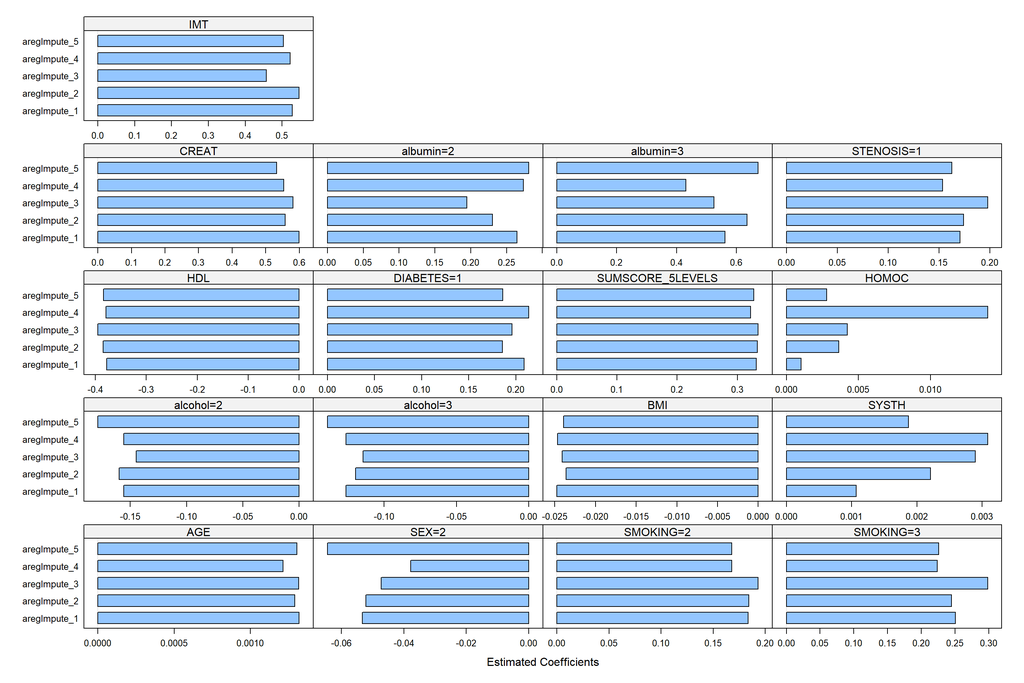

```r
rownames(COXPH.FULL.AREGIMPUTED_12345.Coefficients) <- c("aregImpute_1",
                                                         "aregImpute_2",
                                                         "aregImpute_3",
                                                         "aregImpute_4",
                                                         "aregImpute_5")

barchart(COXPH.FULL.AREGIMPUTED_12345.Coefficients,
         groups=rownames(COXPH.FULL.AREGIMPUTED_12345.Coefficients),
         scales=list(x="free"),
         auto.key = list(columns = 5),
         layout = c(4,5),
         xlab = "Estimated Coefficients",)
```

### 1.2.6 Model Selection

**[A]** Using the imputed data from iteration 3 (aregImputed_3), the full model initially consisted of 14 variables:  
**[A.1]** AGE variable (numeric) coded using its squared value after 50 years [if (AGE>50) then (AGE-50)^2 else 0] called AGE_SQUAREDAFTER50 variable (numeric)  
**[A.2]** SEX variable (factor)  
**[A.3]** SMOKING variable (factor)  
**[A.4]** ALCOHOL variable (factor)  
**[A.5]** BMI variable (numeric)  
**[A.6]** SYSTH variable (numeric)  
**[A.7]** HDL variable (numeric)  
**[A.8]** DIABETES variable (factor)  
**[A.9]** CEREBRAL variable (numeric), CARDIAC variable (numeric), AAA variable (numeric) and PERIPH variable (numeric) coded using their linear combination [CEREBRAL + CARDIAC + (2*AAA) + PERIPH] called SUMSCORE_5LEVELS variable (numeric)  
**[A.10]** HOMOC variable (numeric)  
**[A.11]** CREAT variable (numeric) coded using its logarithm [log(CREAT)] called CREAT_LOG variable (numeric)  
**[A.12]** ALBUMIN variable (factor)  
**[A.13]** STENOSIS variable (factor)  
**[A.14]** IMT variable (numeric)  
**[B]** With backward elimination process based on the AIC criterion applied during variable selection, the reduced model eventually consisted of only 9 remaining variables:  
**[B.1]** AGE variable (numeric) coded using its squared value after 50 years [if (AGE>50) then (AGE-50)^2 else 0] called AGE_SQUAREDAFTER50 variable (numeric)  
**[B.2]** BMI variable (numeric)  
**[B.3]** HDL variable (numeric)  
**[B.4]** DIABETES variable (factor)  
**[B.5]** CEREBRAL variable (numeric), CARDIAC variable (numeric), AAA variable (numeric) and PERIPH variable (numeric) coded using their linear combination [CEREBRAL + CARDIAC + (2*AAA) + PERIPH] called SUMSCORE_5LEVELS variable (numeric)  
**[B.6]** CREAT variable (numeric) coded using its logarithm [log(CREAT)] called CREAT_LOG variable (numeric)  
**[B.7]** ALBUMIN variable (factor)  
**[B.8]** STENOSIS variable (factor)  
**[B.9]** IMT variable (numeric)  
**[C]** The reduced model was justified as the inclusion of the variables creating a full model did not show any significant improvement to model fit (p=0.654, Likelihood Ratio Test).

**Code Chunk | Output**

```r
##################################
# Loading the 3RD imputation results from AREG
# for the subsequent model specification
##################################

##################################
# FULL MODEL
# with 14 variables
##################################

COXPH.FULL.AREGIMPUTED_3 <-cph(Surv(TEVENT,EVENT) ~  ifelse(AGE>50, (AGE-50)^2,0) +
                                 SEX +
                                 SMOKING +
                                 alcohol +
                                 BMI +
                                 SYSTH +
                                 HDL +
                                 DIABETES +
                                 SUMSCORE_5LEVELS +
                                 HOMOC +
                                 log(CREAT) +
                                 albumin +
                                 STENOSIS +
                                 IMT,
                               data = SMART.AREGIMPUTED_3,
                               x=T,
                               y=T,
                               surv=T)
anova(COXPH.FULL.AREGIMPUTED_3)
```

```
##                 Wald Statistics          Response: Surv(TEVENT, EVENT)
##
##  Factor           Chi-Square d.f. P
##  AGE               37.94      1   <.0001
##  SEX                0.12      1   0.7269
##  SMOKING            2.25      2   0.3250
##  alcohol            1.11      2   0.5753
##  BMI                2.88      1   0.0899
##  SYSTH              1.69      1   0.1939
##  HDL                6.08      1   0.0137
##  DIABETES           3.15      1   0.0761
##  SUMSCORE_5LEVELS  36.05      1   <.0001
##  HOMOC              0.24      1   0.6207
##  CREAT             15.67      1   0.0001
##  albumin            7.32      2   0.0257
##  STENOSIS           3.43      1   0.0642
##  IMT                6.57      1   0.0103
##  TOTAL            311.06     17   <.0001
```

```r
summary(COXPH.FULL.AREGIMPUTED_3)
```

```
##              Effects              Response : Surv(TEVENT, EVENT)
##
##  Factor           Low    High   Diff. Effect    S.E.     Lower 0.95 Upper 0.95
##  AGE               52.00  68.00 16.00  0.421290 0.068396  0.287240   0.555340
##   Hazard Ratio     52.00  68.00 16.00  1.523900       NA  1.332700   1.742500
##  BMI               24.11  28.73  4.62 -0.111310 0.065642 -0.239960   0.017347
##   Hazard Ratio     24.11  28.73  4.62  0.894660       NA  0.786660   1.017500
##  SYSTH            127.00 156.00 29.00  0.083927 0.064609 -0.042704   0.210560
##   Hazard Ratio    127.00 156.00 29.00  1.087500       NA  0.958200   1.234400
##  HDL                0.96   1.42  0.46 -0.181520 0.073610 -0.325790  -0.037244
##   Hazard Ratio      0.96   1.42  0.46  0.834000       NA  0.721960   0.963440
##  SUMSCORE_5LEVELS   1.00   5.00  4.00  1.338700 0.222960  0.901750   1.775700
##   Hazard Ratio      1.00   5.00  4.00  3.814200       NA  2.463900   5.904600
##  HOMOC             10.50  16.10  5.60  0.023686 0.047858 -0.070114   0.117490
##   Hazard Ratio     10.50  16.10  5.60  1.024000       NA  0.932290   1.124700
##  CREAT             78.00 101.00 23.00  0.150200 0.037942  0.075835   0.224570
##   Hazard Ratio     78.00 101.00 23.00  1.162100       NA  1.078800   1.251800
##  IMT                0.75   1.07  0.32  0.146240 0.057032  0.034457   0.258020
##   Hazard Ratio      0.75   1.07  0.32  1.157500       NA  1.035100   1.294400
##  SEX - 2:1          1.00   2.00    NA -0.047213 0.135210 -0.312210   0.217790
##   Hazard Ratio      1.00   2.00    NA  0.953880       NA  0.731830   1.243300
##  SMOKING - 1:2      2.00   1.00    NA -0.193240 0.144660 -0.476770   0.090286
##   Hazard Ratio      2.00   1.00    NA  0.824280       NA  0.620780   1.094500
##  SMOKING - 3:2      2.00   3.00    NA  0.105120 0.197840 -0.282640   0.492880
##   Hazard Ratio      2.00   3.00    NA  1.110800       NA  0.753790   1.637000
##  alcohol - 1:3      3.00   1.00    NA  0.114520 0.120600 -0.121850   0.350880
##   Hazard Ratio      3.00   1.00    NA  1.121300       NA  0.885280   1.420300
##  alcohol - 2:3      3.00   2.00    NA -0.030120 0.147370 -0.318970   0.258730
##   Hazard Ratio      3.00   2.00    NA  0.970330       NA  0.726900   1.295300
##  DIABETES - 1:0     1.00   2.00    NA  0.195840 0.110430 -0.020590   0.412270
##   Hazard Ratio      1.00   2.00    NA  1.216300       NA  0.979620   1.510200
##  albumin - 2:1      1.00   2.00    NA  0.194770 0.118990 -0.038447   0.427990
##   Hazard Ratio      1.00   2.00    NA  1.215000       NA  0.962280   1.534200
##  albumin - 3:1      1.00   3.00    NA  0.525450 0.207680  0.118400   0.932500
##   Hazard Ratio      1.00   3.00    NA  1.691200       NA  1.125700   2.540900
##  STENOSIS - 1:0     1.00   2.00    NA  0.197860 0.106910 -0.011678   0.407410
##   Hazard Ratio      1.00   2.00    NA  1.218800       NA  0.988390   1.502900
```

```r
COXPH.FULL.AREGIMPUTED_3
```

```
## Cox Proportional Hazards Model
##
## cph(formula = Surv(TEVENT, EVENT) ~ ifelse(AGE > 50, (AGE - 50)^2,
##     0) + SEX + SMOKING + alcohol + BMI + SYSTH + HDL + DIABETES +
##     SUMSCORE_5LEVELS + HOMOC + log(CREAT) + albumin + STENOSIS +
##     IMT, data = SMART.AREGIMPUTED_3, x = T, y = T, surv = T)
##
##                        Model Tests      Discrimination
##                                                Indexes
## Obs      3873    LR chi2    274.70      R2       0.082
## Events    460    d.f.           17    R2(17,3873)0.064
## Center 3.2859    Pr(> chi2) 0.0000     R2(17,460)0.429
##                  Score chi2 344.55      Dxy      0.391
##                  Pr(> chi2) 0.0000
##
##                  Coef    S.E.   Wald Z Pr(>|Z|)
## AGE               0.0013 0.0002  6.16  <0.0001
## SEX=2            -0.0472 0.1352 -0.35  0.7269
## SMOKING=2         0.1932 0.1447  1.34  0.1816
## SMOKING=3         0.2984 0.2320  1.29  0.1985
## alcohol=2        -0.1446 0.1659 -0.87  0.3833
## alcohol=3        -0.1145 0.1206 -0.95  0.3423
## BMI              -0.0241 0.0142 -1.70  0.0899
## SYSTH             0.0029 0.0022  1.30  0.1939
## HDL              -0.3946 0.1600 -2.47  0.0137
## DIABETES=1        0.1958 0.1104  1.77  0.0761
## SUMSCORE_5LEVELS  0.3347 0.0557  6.00  <0.0001
## HOMOC             0.0042 0.0085  0.49  0.6207
## CREAT             0.5812 0.1468  3.96  <0.0001
## albumin=2         0.1948 0.1190  1.64  0.1017
## albumin=3         0.5255 0.2077  2.53  0.0114
## STENOSIS=1        0.1979 0.1069  1.85  0.0642
## IMT               0.4570 0.1782  2.56  0.0103
```

```r
rcorr.cens(-as.numeric(COXPH.FULL.AREGIMPUTED_3$linear.pred),COXPH.FULL.AREGIMPUTED_3$y)[1]
```

```
##   C Index
## 0.6952528
```

```r
##################################
# REDUCED MODEL
# with 14 variables evaluated
# using backward stepwise selection
# resulting to 9 variables
##################################

BackwardElimination <- fastbw(COXPH.FULL.AREGIMPUTED_3,
                           rule="aic",
                           type="individual")

COXPH.BACKWARDELIMINATION.AREGIMPUTED_3 <- update(COXPH.FULL.AREGIMPUTED_3,                                              ~COXPH.FULL.AREGIMPUTED_3$x[,BackwardElimination$parms.kept])

COXPH.BACKWARDELIMINATION.AREGIMPUTED_3
```

```
## Cox Proportional Hazards Model
##
## cph(formula = Surv(TEVENT, EVENT) ~ COXPH.FULL.AREGIMPUTED_3$x[,
##     BackwardElimination$parms.kept], data = SMART.AREGIMPUTED_3,
##     x = T, y = T, surv = T)
##
##                        Model Tests      Discrimination
##                                                Indexes
## Obs      3873    LR chi2    269.65      R2       0.080
## Events    460    d.f.           10    R2(10,3873)0.065
## Center 2.9008    Pr(> chi2) 0.0000     R2(10,460)0.431
##                  Score chi2 340.60      Dxy      0.384
##                  Pr(> chi2) 0.0000
##
##                  Coef    S.E.   Wald Z Pr(>|Z|)
## AGE               0.0013 0.0002  6.47  <0.0001
## BMI              -0.0249 0.0141 -1.76  0.0780
## HDL              -0.4111 0.1528 -2.69  0.0071
## DIABETES=1        0.1896 0.1097  1.73  0.0840
## SUMSCORE_5LEVELS  0.3452 0.0540  6.39  <0.0001
## CREAT             0.6076 0.1334  4.56  <0.0001
## albumin=2         0.2321 0.1176  1.97  0.0485
## albumin=3         0.5644 0.2060  2.74  0.0061
## STENOSIS=1        0.2291 0.1051  2.18  0.0293
## IMT               0.5059 0.1749  2.89  0.0038
```

```r
COXPH.REDUCED.AREGIMPUTED_3 <-cph(Surv(TEVENT,EVENT) ~  ifelse(AGE>50, (AGE-50)^2,0) +
                                 BMI +
                                 HDL+
                                 DIABETES +
                                 SUMSCORE_5LEVELS +
                                 log(CREAT) +
                                 albumin +
                                 STENOSIS +
                                 IMT,
                               data = SMART.AREGIMPUTED_3,
                               x=T,
                               y=T,
                               surv=T)

anova(COXPH.REDUCED.AREGIMPUTED_3)
```

```
##                 Wald Statistics          Response: Surv(TEVENT, EVENT)
##
##  Factor           Chi-Square d.f. P
##  AGE               41.87      1   <.0001
##  BMI                3.11      1   0.0780
##  HDL                7.24      1   0.0071
##  DIABETES           2.99      1   0.0840
##  SUMSCORE_5LEVELS  40.87      1   <.0001
##  CREAT             20.75      1   <.0001
##  albumin            9.09      2   0.0106
##  STENOSIS           4.75      1   0.0293
##  IMT                8.37      1   0.0038
##  TOTAL            309.72     10   <.0001
```

```r
summary(COXPH.REDUCED.AREGIMPUTED_3)
```

```
##              Effects              Response : Surv(TEVENT, EVENT)
##
##  Factor           Low   High   Diff. Effect   S.E.     Lower 0.95 Upper 0.95
##  AGE              52.00  68.00 16.00  0.42636 0.065888  0.2972200  0.555500
##   Hazard Ratio    52.00  68.00 16.00  1.53170       NA  1.3461000  1.742800
##  BMI              24.11  28.73  4.62 -0.11510 0.065302 -0.2430900  0.012885
##   Hazard Ratio    24.11  28.73  4.62  0.89127       NA  0.7842000  1.013000
##  HDL               0.96   1.42  0.46 -0.18912 0.070306 -0.3269100 -0.051318
##   Hazard Ratio     0.96   1.42  0.46  0.82769       NA  0.7211500  0.949980
##  SUMSCORE_5LEVELS  1.00   5.00  4.00  1.38100 0.216010  0.9575800  1.804300
##   Hazard Ratio     1.00   5.00  4.00  3.97870       NA  2.6054000  6.076000
##  CREAT            78.00 101.00 23.00  0.15700 0.034464  0.0894550  0.224550
##   Hazard Ratio    78.00 101.00 23.00  1.17000       NA  1.0936000  1.251800
##  IMT               0.75   1.07  0.32  0.16190 0.055968  0.0522010  0.271590
##   Hazard Ratio     0.75   1.07  0.32  1.17570       NA  1.0536000  1.312000
##  DIABETES - 1:0    1.00   2.00    NA  0.18957 0.109700 -0.0254450  0.404580
##   Hazard Ratio     1.00   2.00    NA  1.20870       NA  0.9748800  1.498700
##  albumin - 2:1     1.00   2.00    NA  0.23207 0.117640  0.0014922  0.462640
##   Hazard Ratio     1.00   2.00    NA  1.26120       NA  1.0015000  1.588300
##  albumin - 3:1     1.00   3.00    NA  0.56442 0.206000  0.1606600  0.968180
##   Hazard Ratio     1.00   3.00    NA  1.75840       NA  1.1743000  2.633100
##  STENOSIS - 1:0    1.00   2.00    NA  0.22905 0.105070  0.0231120  0.434990
##   Hazard Ratio     1.00   2.00    NA  1.25740       NA  1.0234000  1.545000
```

```r
COXPH.REDUCED.AREGIMPUTED_3
```

```
## Cox Proportional Hazards Model
##
## cph(formula = Surv(TEVENT, EVENT) ~ ifelse(AGE > 50, (AGE - 50)^2,
##     0) + BMI + HDL + DIABETES + SUMSCORE_5LEVELS + log(CREAT) +
##     albumin + STENOSIS + IMT, data = SMART.AREGIMPUTED_3, x = T,
##     y = T, surv = T)
##
##                        Model Tests      Discrimination
##                                                Indexes
## Obs      3873    LR chi2    269.65      R2       0.080
## Events    460    d.f.           10    R2(10,3873)0.065
## Center 2.9008    Pr(> chi2) 0.0000     R2(10,460)0.431
##                  Score chi2 340.60      Dxy      0.384
##                  Pr(> chi2) 0.0000
##
##                  Coef    S.E.   Wald Z Pr(>|Z|)
## AGE               0.0013 0.0002  6.47  <0.0001
## BMI              -0.0249 0.0141 -1.76  0.0780
## HDL              -0.4111 0.1528 -2.69  0.0071
## DIABETES=1        0.1896 0.1097  1.73  0.0840
## SUMSCORE_5LEVELS  0.3452 0.0540  6.39  <0.0001
## CREAT             0.6076 0.1334  4.56  <0.0001
## albumin=2         0.2321 0.1176  1.97  0.0485
## albumin=3         0.5644 0.2060  2.74  0.0061
## STENOSIS=1        0.2291 0.1051  2.18  0.0293
## IMT               0.5059 0.1749  2.89  0.0038
```

```r
rcorr.cens(-as.numeric(COXPH.REDUCED.AREGIMPUTED_3$linear.pred),COXPH.REDUCED.AREGIMPUTED_3$y)[1]
```

```
##   C Index
## 0.6917632
```

```r
##################################
# Formulating the FULL and REDUCED models
##################################
SMART.AREGIMPUTED_3$AGE_SQUAREDAFTER50 <- ifelse(SMART.AREGIMPUTED_3$AGE>50, (SMART.AREGIMPUTED_3$AGE-50)^2,0)
SMART.AREGIMPUTED_3$CREAT_LOG <- log(SMART.AREGIMPUTED_3$CREAT)


COXPH.AREGIMPUTED_3.SurvivalResponse <- "Surv(TEVENT, EVENT)"
COXPH.AREGIMPUTED_3.SurvivalPredictorFull <- c("AGE_SQUAREDAFTER50",
                                               "SEX",
                                               "SMOKING",
                                               "alcohol",
                                               "BMI",
                                               "SYSTH",
                                               "HDL",
                                               "DIABETES",
                                               "SUMSCORE_5LEVELS",
                                               "HOMOC",
                                               "CREAT_LOG",
                                               "albumin",
                                               "STENOSIS",
                                               "IMT")
COXPH.AREGIMPUTED_3.SurvivalPredictorReduced <- c("AGE_SQUAREDAFTER50",
                                               "BMI",
                                               "HDL",
                                               "DIABETES",
                                               "SUMSCORE_5LEVELS",
                                               "CREAT_LOG",
                                               "albumin",
                                               "STENOSIS",
                                               "IMT")

COXPH.AREGIMPUTED_3.CoxPHModelSummary <- SMART.AREGIMPUTED_3 %>%
  finalfit(COXPH.AREGIMPUTED_3.SurvivalResponse,
           COXPH.AREGIMPUTED_3.SurvivalPredictorFull,
           COXPH.AREGIMPUTED_3.SurvivalPredictorReduced,
           keep_models = TRUE,
           add_dependent_label = FALSE) %>%
  rename("Overall Survival" = label) %>%
  rename(" " = levels) %>%
  rename("  " = all)

kable(COXPH.AREGIMPUTED_3.CoxPHModelSummary)
```

|  | Overall Survival |  |  | HR (univariable) | HR (multivariable full) | HR (multivariable) |
| --- | --- | --- | --- | --- | --- | --- |
| 1 | AGE_SQUAREDAFTER50 | Mean (SD) | 189.0 (217.0) | 1.00 (1.00-1.00, p<0.001) | 1.00 (1.00-1.00, p<0.001) | 1.00 (1.00-1.00, p<0.001) |
| 15 | SEX | 1 | 2897 (74.8) | - | - | - |
| 16 |  | 2 | 976 (25.2) | 0.67 (0.53-0.85, p=0.001) | 0.95 (0.73-1.24, p=0.725) | - |
| 17 | SMOKING | 1 | 695 (17.9) | - | - | - |
| 18 |  | 2 | 2731 (70.5) | 1.29 (0.99-1.68, p=0.060) | 1.21 (0.91-1.61, p=0.182) | - |
| 19 |  | 3 | 447 (11.5) | 1.16 (0.74-1.80, p=0.516) | 1.35 (0.86-2.12, p=0.199) | - |
| 5 | alcohol | 1 | 759 (19.6) | - | - | - |
| 6 |  | 2 | 410 (10.6) | 1.02 (0.74-1.39, p=0.914) | 0.87 (0.63-1.20, p=0.383) | - |
| 7 |  | 3 | 2704 (69.8) | 0.78 (0.62-0.97, p=0.024) | 0.89 (0.70-1.13, p=0.342) | - |
| 8 | BMI | Mean (SD) | 26.7 (3.8) | 0.98 (0.95-1.00, p=0.052) | 0.98 (0.95-1.00, p=0.090) | 0.98 (0.95-1.00, p=0.078) |
| 23 | SYSTH | Mean (SD) | 143.0 (22.2) | 1.01 (1.01-1.02, p<0.001) | 1.00 (1.00-1.01, p=0.194) | - |
| 12 | HDL | Mean (SD) | 1.2 (0.4) | 0.60 (0.45-0.80, p<0.001) | 0.67 (0.49-0.92, p=0.014) | 0.66 (0.49-0.89, p=0.007) |
| 10 | DIABETES | 0 | 3024 (78.1) | - | - | - |
| 11 |  | 1 | 849 (21.9) | 1.47 (1.20-1.80, p<0.001) | 1.22 (0.98-1.51, p=0.076) | 1.21 (0.97-1.50, p=0.084) |
| 22 | SUMSCORE_5LEVELS | Mean (SD) | 1.3 (0.6) | 1.73 (1.57-1.90, p<0.001) | 1.40 (1.25-1.56, p<0.001) | 1.41 (1.27-1.57, p<0.001) |
| 13 | HOMOC | Mean (SD) | 14.1 (5.4) | 1.05 (1.04-1.06, p<0.001) | 1.00 (0.99-1.02, p=0.620) | - |
| 9 | CREAT_LOG | Mean (SD) | 4.5 (0.3) | 2.93 (2.44-3.53, p<0.001) | 1.79 (1.34-2.38, p<0.001) | 1.83 (1.41-2.38, p<0.001) |
| 2 | albumin | 1 | 3040 (78.5) | - | - | - |
| 3 |  | 2 | 696 (18.0) | 1.94 (1.56-2.41, p<0.001) | 1.22 (0.96-1.53, p=0.101) | 1.26 (1.00-1.59, p=0.048) |
| 4 |  | 3 | 137 (3.5) | 3.75 (2.70-5.19, p<0.001) | 1.69 (1.12-2.54, p=0.012) | 1.76 (1.17-2.63, p=0.006) |
| 20 | STENOSIS | 0 | 3136 (81.0) | - | - | - |
| 21 |  | 1 | 737 (19.0) | 1.75 (1.44-2.12, p<0.001) | 1.22 (0.99-1.50, p=0.064) | 1.26 (1.02-1.54, p=0.029) |
| 14 | IMT | Mean (SD) | 0.9 (0.3) | 3.58 (2.68-4.76, p<0.001) | 1.58 (1.11-2.24, p=0.010) | 1.66 (1.18-2.34, p=0.004) |

```r
##################################
# Conducting a likelihood ratio test
# to compare the FULL and REDUCED models
##################################
COXPH.FULLFINAL.AREGIMPUTED_3 <- coxph(Surv(TEVENT,EVENT) ~  AGE_SQUAREDAFTER50 +
                                 SEX +
                                 SMOKING +
                                 alcohol +
                                 BMI +
                                 SYSTH +
                                 HDL +
                                 DIABETES +
                                 SUMSCORE_5LEVELS +
                                 HOMOC +
                                 CREAT_LOG +
                                 albumin +
                                 STENOSIS +
                                 IMT,
                               data = SMART.AREGIMPUTED_3)

COXPH.REDUCEDFINAL.AREGIMPUTED_3 <- coxph(Surv(TEVENT,EVENT) ~  AGE_SQUAREDAFTER50 +
                                 BMI +
                                 HDL+
                                 DIABETES +
                                 SUMSCORE_5LEVELS +
                                 CREAT_LOG +
                                 albumin +
                                 STENOSIS +
                                 IMT,
                               data = SMART.AREGIMPUTED_3)

anova(COXPH.REDUCEDFINAL.AREGIMPUTED_3,
      COXPH.FULLFINAL.AREGIMPUTED_3,
      test="LRT")
```

```
## Analysis of Deviance Table
##  Cox model: response is  Surv(TEVENT, EVENT)
##  Model 1: ~ AGE_SQUAREDAFTER50 + BMI + HDL + DIABETES + SUMSCORE_5LEVELS + CREAT_LOG + albumin + STENOSIS + IMT
##  Model 2: ~ AGE_SQUAREDAFTER50 + SEX + SMOKING + alcohol + BMI + SYSTH + HDL + DIABETES + SUMSCORE_5LEVELS + HOMOC + CREAT_LOG + albumin + STENOSIS + IMT
##    loglik  Chisq Df Pr(>|Chi|)
## 1 -3370.0
## 2 -3367.4 5.0507  7     0.6538
```

### 1.2.7 Model Performance Estimation

**Code Chunk | Output**

```r
##################################
# Summarizing the FINAL REDUCED model
##################################
summary(COXPH.REDUCEDFINAL.AREGIMPUTED_3)
```

```
## Call:
## coxph(formula = Surv(TEVENT, EVENT) ~ AGE_SQUAREDAFTER50 + BMI +
##     HDL + DIABETES + SUMSCORE_5LEVELS + CREAT_LOG + albumin +
##     STENOSIS + IMT, data = SMART.AREGIMPUTED_3)
##
##   n= 3873, number of events= 460
##
##                          coef  exp(coef)   se(coef)      z Pr(>|z|)
## AGE_SQUAREDAFTER50  0.0013327  1.0013336  0.0002059  6.473 9.62e-11 ***
## BMI                -0.0249103  0.9753974  0.0141344 -1.762  0.07800 .
## HDL                -0.4112635  0.6628123  0.1528392 -2.691  0.00713 **
## DIABETES1           0.1894940  1.2086379  0.1097039  1.727  0.08411 .
## SUMSCORE_5LEVELS    0.3452748  1.4123780  0.0540046  6.393 1.62e-10 ***
## CREAT_LOG           0.6064023  1.8338220  0.1334447  4.544 5.51e-06 ***
## albumin2            0.2321931  1.2613633  0.1176337  1.974  0.04840 *
## albumin3            0.5636867  1.7571386  0.2060667  2.735  0.00623 **
## STENOSIS1           0.2290771  1.2574389  0.1050720  2.180  0.02924 *
## IMT                 0.5059860  1.6586202  0.1748953  2.893  0.00381 **
## ---
## Signif. codes:  0 '***' 0.001 '**' 0.01 '*' 0.05 '.' 0.1 ' ' 1
##
##                    exp(coef) exp(-coef) lower .95 upper .95
## AGE_SQUAREDAFTER50    1.0013     0.9987    1.0009    1.0017
## BMI                   0.9754     1.0252    0.9487    1.0028
## HDL                   0.6628     1.5087    0.4912    0.8943
## DIABETES1             1.2086     0.8274    0.9748    1.4986
## SUMSCORE_5LEVELS      1.4124     0.7080    1.2705    1.5701
## CREAT_LOG             1.8338     0.5453    1.4118    2.3820
## albumin2              1.2614     0.7928    1.0016    1.5884
## albumin3              1.7571     0.5691    1.1733    2.6315
## STENOSIS1             1.2574     0.7953    1.0234    1.5450
## IMT                   1.6586     0.6029    1.1773    2.3368
##
## Concordance= 0.692  (se = 0.014 )
## Likelihood ratio test= 269.6  on 10 df,   p=<2e-16
## Wald test            = 309.4  on 10 df,   p=<2e-16
## Score (logrank) test = 340.6  on 10 df,   p=<2e-16
```

```r
##################################
# Describing the main effects
##################################
tbl_regression(COXPH.REDUCEDFINAL.AREGIMPUTED_3,
               exponentiate = TRUE)
```

| **Characteristic** | **HR**<sup>1</sup> | **95% CI**<sup>1</sup> | **p-value** |
| --- | --- | --- | --- |
| AGE_SQUAREDAFTER50 | 1.00 | 1.00, 1.00 | <0.001 |
| BMI | 0.98 | 0.95, 1.00 | 0.078 |
| HDL | 0.66 | 0.49, 0.89 | 0.007 |
| DIABETES |  |  |  |
| 0 | — | — |  |
| 1 | 1.21 | 0.97, 1.50 | 0.084 |
| SUMSCORE_5LEVELS | 1.41 | 1.27, 1.57 | <0.001 |
| CREAT_LOG | 1.83 | 1.41, 2.38 | <0.001 |
| albumin |  |  |  |
| 1 | — | — |  |
| 2 | 1.26 | 1.00, 1.59 | 0.048 |
| 3 | 1.76 | 1.17, 2.63 | 0.006 |
| STENOSIS |  |  |  |
| 0 | — | — |  |
| 1 | 1.26 | 1.02, 1.54 | 0.029 |
| IMT | 1.66 | 1.18, 2.34 | 0.004 |

<sup>1</sup> HR = Hazard Ratio, CI = Confidence Interval

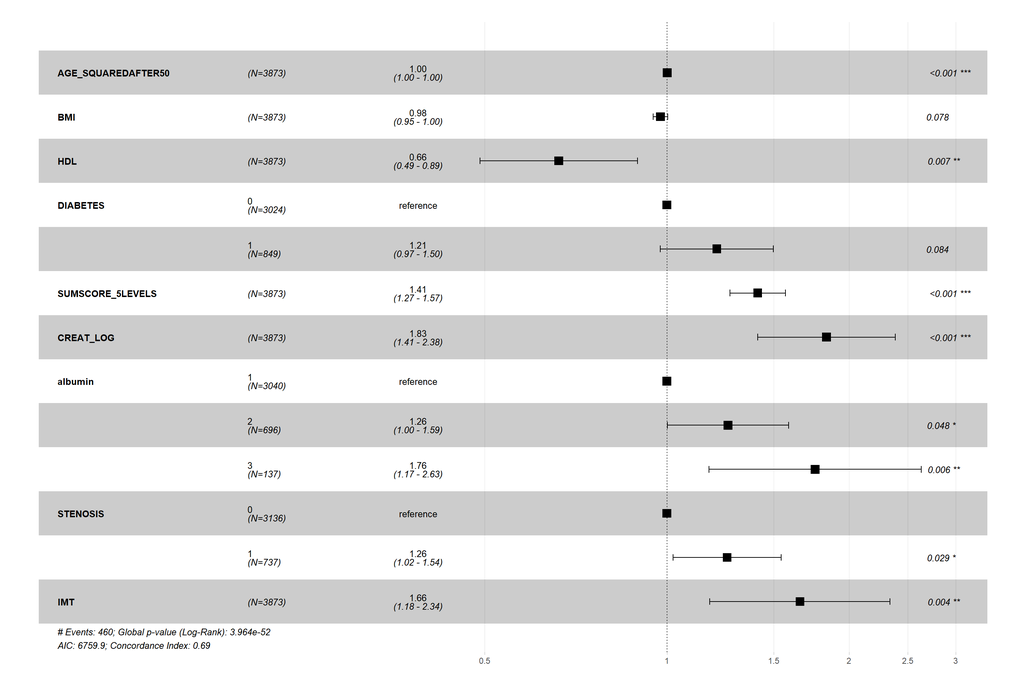

```r
##################################
# Formulating the forest plot
##################################
(ggforest(COXPH.REDUCEDFINAL.AREGIMPUTED_3,
          data=SMART.AREGIMPUTED_3,
          main = "",
          fontsize = 0.90))
```

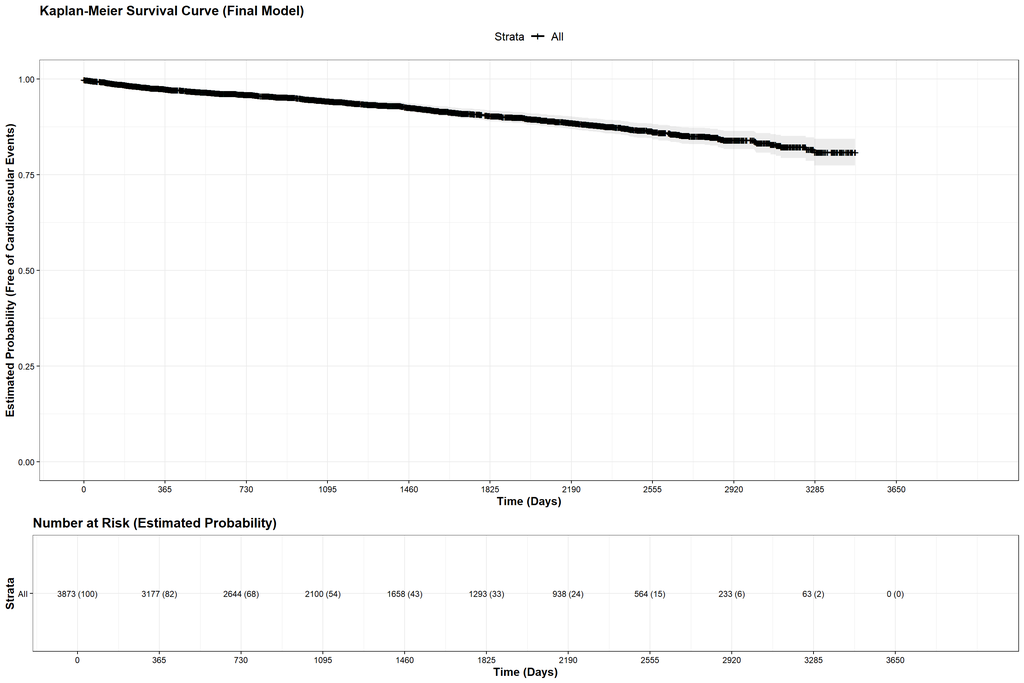

```r
##################################
# Plotting the Kaplan-Meier survival curves
##################################
COXPH.REDUCEDFINAL.AREGIMPUTED_3.KMEstimates <- survfit(COXPH.REDUCEDFINAL.AREGIMPUTED_3,
                                                                 data = SMART.AREGIMPUTED_3)

COXPH.REDUCEDFINAL.AREGIMPUTED_3.KMPlot <- ggsurvplot(COXPH.REDUCEDFINAL.AREGIMPUTED_3.KMEstimates,
                                                      title = "Kaplan-Meier Survival Curve (Final Model)",
                                                      pval = FALSE,
                                                      conf.int = TRUE,
                                                      conf.int.style = "ribbon",
                                                      xlab = "Time (Days)",
                                                      ylab="Estimated Probability (Free of Cardiovascular Events)",
                                                      break.time.by = 365,
                                                      ggtheme = theme_bw(),
                                                      risk.table = "abs_pct",
                                                      risk.table.title="Number at Risk (Estimated Probability)",
                                                      risk.table.y.text.col = FALSE,
                                                      risk.table.y.text = TRUE,
                                                      fontsize = 3,
                                                      ncensor.plot = FALSE,
                                                      surv.median.line = "hv",
                                                      palette = c("#000000"))

ggpar(COXPH.REDUCEDFINAL.AREGIMPUTED_3.KMPlot,
      font.title = c(14,"bold"),
      font.x = c(12,"bold"),
      font.y = c(12,"bold"),
      font.legend=c(12),
      font.xtickslab=c(9,"black"),
      font.ytickslab=c(9,"black"))
```

```r
##################################
# Testing for the proportional hazards assumption
##################################
(COXPH.REDUCEDFINAL.AREGIMPUTED_3.PHAssumptionCheck <- cox.zph(COXPH.REDUCEDFINAL.AREGIMPUTED_3))
```

```
##                      chisq df     p
## AGE_SQUAREDAFTER50  6.2279  1 0.013
## BMI                 0.3371  1 0.561
## HDL                 0.0483  1 0.826
## DIABETES            0.0069  1 0.934
## SUMSCORE_5LEVELS    4.0453  1 0.044
## CREAT_LOG           0.1978  1 0.657
## albumin             2.6737  2 0.263
## STENOSIS            1.4148  1 0.234
## IMT                 0.8929  1 0.345
## GLOBAL             12.0725 10 0.280
```

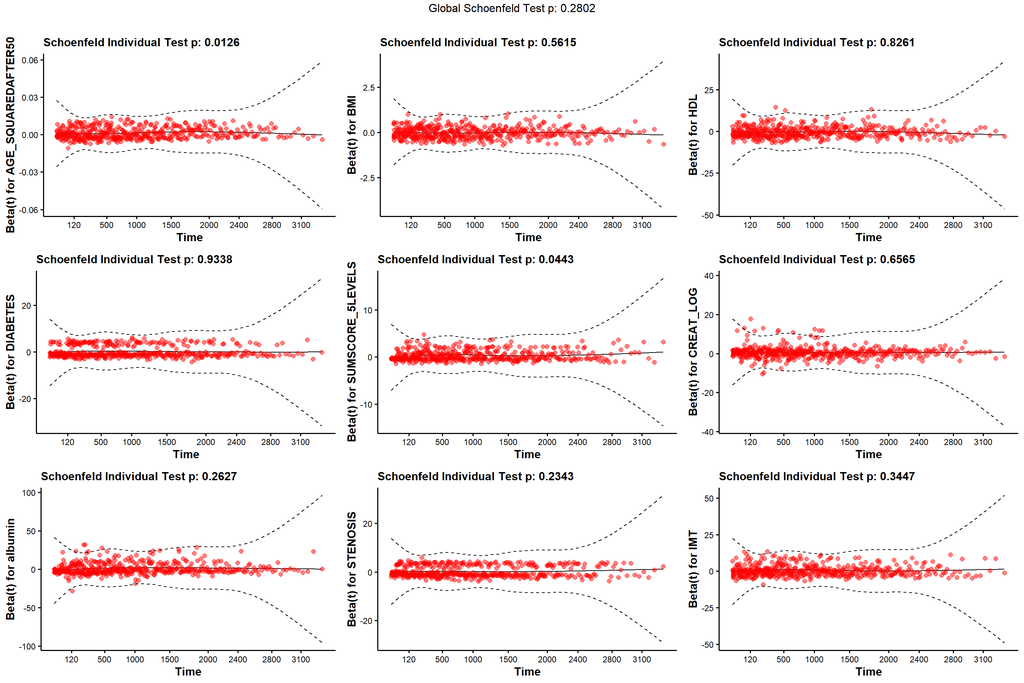

```r
##################################
# Formulating the graphical verification
# of the proportional hazards assumption test results
# using the scaled Schoenfeld residuals against time
##################################
(COXPH.REDUCEDFINAL.AREGIMPUTED_3.PHAssumptionPlot <- ggcoxzph(COXPH.REDUCEDFINAL.AREGIMPUTED_3.PHAssumptionCheck,
         point.col = "red",
         point.size = 2,
         point.shape = 19,
         point.alpha = 0.50,
  ggtheme = theme_survminer(),
  font.main = c(12,"bold"),
  font.x = c(12,"bold"),
  font.y = c(12,"bold"),
  font.xtickslab=c(9,"black"),
  font.ytickslab=c(9,"black")))
```

### 1.2.8 Model Performance Validation

**[A]** The entire process of model development including variable selection was internally validated using a 200-cycle bootstrap to determine the optimism-adjusted model performance. Results showed that:  
**[A.1]** Only 183 random seeds of the 200 cycles resulted to valid models. 17 of the random seeds did not generate final models potentially due to the unmet AIC criterion applied during model selection.  
**[A.2]** Optimism in terms of model discrimination using the concordance statistic was estimated to be reasonably low at 0.035. In effect, the optimism-adjusted concordance statistic was computed to be 0.657 from the previously determined optimistic value of 0.692. Results indicate that the overfitting effects during model development were minimal.

**Code Chunk | Output**

```r
##################################
# Implementing internal cross validation
##################################

##################################
# Determining the performance of the
# Model formulated from original data
# And evaluated on original data
##################################

ICV_Data <- SMART.AREGIMPUTED_3
ICV_Survival <- Surv(time=ICV_Data$TEVENT, event=ICV_Data$EVENT)
ICV_Original_CoxPH_Full <- cph(ICV_Survival ~ AGE_SQUAREDAFTER50 +
                                 SEX +
                                 SMOKING +
                                 alcohol +
                                 BMI +
                                 SYSTH +
                                 HDL +
                                 DIABETES +
                                 SUMSCORE_5LEVELS +
                                 HOMOC +
                                 CREAT_LOG +
                                 albumin +
                                 STENOSIS +
                                 IMT,
                               data=ICV_Data,
                               x=T,
                               y=T)


ICV_Original_CoxPH_Backward <- fastbw(ICV_Original_CoxPH_Full,
                              rule="aic",
                              type="individual")

ICV_Original_CoxPH_Reduced <- update(ICV_Original_CoxPH_Full,
                                     ~ICV_Original_CoxPH_Full$x[,ICV_Original_CoxPH_Backward$parms.kept])

ICV_Original_CoxPH_Reduced_Coef <- as.data.frame(coef(ICV_Original_CoxPH_Reduced))

ICV_Original_CoxPH_Full_CoefAdjusted <- ICV_Original_CoxPH_Full$x[,(colnames(ICV_Original_CoxPH_Full$x) %in% rownames(ICV_Original_CoxPH_Reduced_Coef))]

ICV_OriginalOnOriginal_CoxPH_Reduced.LP <- ICV_Original_CoxPH_Full_CoefAdjusted %*% coef(ICV_Original_CoxPH_Reduced)

ICV_OriginalOnOriginal_CoxPH_Reduced.Concordance <- rcorr.cens(-as.numeric(ICV_OriginalOnOriginal_CoxPH_Reduced.LP),ICV_Original_CoxPH_Reduced$y)[1]

ICV_OriginalOnOriginal_CoxPH_Reduced.Concordance[[1]]
```

```
## [1] 0.6917632
```

```r
##################################
# Conducting bootstrap validation
##################################

######################################
# Generating a random number list
######################################
set.seed(123456789)
RandomSeedList <- (sample.int(99999999,200))
length(RandomSeedList)
```

```
## [1] 200
```

```r
ICV_BootstrapOnBootstrap_CoxPH_Reduced.Concordance.List <- c()
ICV_BootstrapOnOriginal_CoxPH_Reduced.Concordance.List <- c()
ICV_CoxPH_Reduced.Concordance.Optimism.List <- c()
ProcessedSeed.List <- c()

######################################
# Implementing the bootstrap cycles
######################################

for (r in 1:length(RandomSeedList)) {

  ##################################
  # Generating the bootstrap data
  ##################################

  (SelectedSeed <- as.integer(RandomSeedList[r]))
  set.seed(SelectedSeed)
  ICV_BootstrapRow <- sample(nrow(ICV_Data),
                              replace=T)

  ICV_BootstrapData <- ICV_Data[ICV_BootstrapRow,]

  ICV_BootstrapSurvival <- Surv(time=ICV_BootstrapData$TEVENT, event=ICV_BootstrapData$EVENT)

  ##################################
  # Formulating the FULL
  # Cox Proportional Hazards Model
  # Using the bootstrap data
  ##################################

  ICV_Bootstrap_CoxPH_Full <- cph(ICV_Survival ~ AGE_SQUAREDAFTER50 +
                                    SEX +
                                    SMOKING +
                                    alcohol +
                                    BMI +
                                    SYSTH +
                                    HDL +
                                    DIABETES +
                                    SUMSCORE_5LEVELS +
                                    HOMOC +
                                    CREAT_LOG +
                                    albumin +
                                    STENOSIS +
                                    IMT,
                                  data=ICV_BootstrapData,
                                  x=T,
                                  y=T)

  ##################################
  # Conducting variable selection
  # Backward elimination
  ##################################

  ICV_Bootstrap_CoxPH_Backward <- fastbw(ICV_Bootstrap_CoxPH_Full,
                                         rule="aic",
                                         type="individual")

  ##################################
  # Ignoring instances when no
  # Reduced model is formulated
  # Due to failure to meet
  # The final model criterion
  ##################################

  if(is.null(ICV_Bootstrap_CoxPH_Backward$factors.kept)!=TRUE) {

    (ProcessedSeed <- as.integer(RandomSeedList[r]))

    print(paste0("Implementing bootstrap cycle ",r))

    ##################################
    # Formulating the REDUCED
    # Cox Proportional Hazards Model
    # Using the bootstrap data
    ##################################

    ICV_Bootstrap_CoxPH_Reduced <- update(ICV_Bootstrap_CoxPH_Full,
                                          ~ICV_Bootstrap_CoxPH_Full$x[,ICV_Bootstrap_CoxPH_Backward$parms.kept, drop = FALSE])

    ICV_Bootstrap_CoxPH_Reduced_Coef <- as.data.frame(coef(ICV_Bootstrap_CoxPH_Reduced))

    ICV_Bootstrap_CoxPH_Reduced_Coef

    ICV_Bootstrap_CoxPH_Full_CoefAdjusted <- ICV_Bootstrap_CoxPH_Full$x[,(colnames(ICV_Bootstrap_CoxPH_Full$x) %in% rownames(ICV_Bootstrap_CoxPH_Reduced_Coef)), drop = FALSE]

    ##################################
    # Determining the performance of the
    # Model formulated from bootstrap data
    # And evaluated on bootstrap data
    ##################################

    ICV_BootstrapOnBootstrap_CoxPH_Reduced.LP <- ICV_Bootstrap_CoxPH_Full_CoefAdjusted %*% coef(ICV_Bootstrap_CoxPH_Reduced)

    ICV_BootstrapOnBootstrap_CoxPH_Reduced.Concordance <- rcorr.cens(-as.numeric(ICV_BootstrapOnBootstrap_CoxPH_Reduced.LP),ICV_Bootstrap_CoxPH_Reduced$y)[1]

    ICV_BootstrapOnBootstrap_CoxPH_Reduced.Concordance

    ICV_Original_CoxPH_Full_CoefAdjusted <- ICV_Original_CoxPH_Full$x[,(colnames(ICV_Original_CoxPH_Full$x) %in% rownames(ICV_Bootstrap_CoxPH_Reduced_Coef)), drop = FALSE]

    ##################################
    # Determining the performance of the
    # Model formulated from bootstrap data
    # And evaluated on original data
    ##################################

    ICV_BootstrapOnOriginal_CoxPH_Reduced.LP <- ICV_Original_CoxPH_Full_CoefAdjusted %*% coef(ICV_Bootstrap_CoxPH_Reduced)

    ICV_BootstrapOnOriginal_CoxPH_Reduced.Concordance <- rcorr.cens(-as.numeric(ICV_BootstrapOnOriginal_CoxPH_Reduced.LP),ICV_Original_CoxPH_Reduced$y)[1]

    ICV_BootstrapOnOriginal_CoxPH_Reduced.Concordance

    ##################################
    # Computing for the individual
    # Estimated performance optimism
    ##################################

    ICV_CoxPH_Reduced.Concordance.Optimism <- ICV_BootstrapOnBootstrap_CoxPH_Reduced.Concordance - ICV_BootstrapOnOriginal_CoxPH_Reduced.Concordance

    ICV_CoxPH_Reduced.Concordance.Optimism

    ProcessedSeed.List <- append(ProcessedSeed.List,ProcessedSeed)
    ICV_BootstrapOnBootstrap_CoxPH_Reduced.Concordance.List <- append(ICV_BootstrapOnBootstrap_CoxPH_Reduced.Concordance.List,ICV_BootstrapOnBootstrap_CoxPH_Reduced.Concordance[[1]])
    ICV_BootstrapOnOriginal_CoxPH_Reduced.Concordance.List <- append(ICV_BootstrapOnOriginal_CoxPH_Reduced.Concordance.List,ICV_BootstrapOnOriginal_CoxPH_Reduced.Concordance[[1]])
    ICV_CoxPH_Reduced.Concordance.Optimism.List <- append(ICV_CoxPH_Reduced.Concordance.Optimism.List,ICV_CoxPH_Reduced.Concordance.Optimism)

  }


}
```

```
## [1] "Implementing bootstrap cycle 1"
## [1] "Implementing bootstrap cycle 2"
## [1] "Implementing bootstrap cycle 3"
## [1] "Implementing bootstrap cycle 4"
## [1] "Implementing bootstrap cycle 5"
## [1] "Implementing bootstrap cycle 6"
## [1] "Implementing bootstrap cycle 7"
## [1] "Implementing bootstrap cycle 8"
## [1] "Implementing bootstrap cycle 9"
## [1] "Implementing bootstrap cycle 10"
## [1] "Implementing bootstrap cycle 11"
## [1] "Implementing bootstrap cycle 12"
## [1] "Implementing bootstrap cycle 13"
## [1] "Implementing bootstrap cycle 14"
## [1] "Implementing bootstrap cycle 15"
```

[output cut: 168 more lines]

```r
##################################
# Consolidating all the individual
# Estimated performance optimism
##################################

ICV_CoxPH_Reduced.Concordance.EstimatedOptimismSummary <- cbind(seq(1:length(ProcessedSeed.List)),
                                                                ProcessedSeed.List,
                                                                ICV_BootstrapOnBootstrap_CoxPH_Reduced.Concordance.List,
                                                                ICV_BootstrapOnOriginal_CoxPH_Reduced.Concordance.List,
                                                                ICV_CoxPH_Reduced.Concordance.Optimism.List)

ICV_CoxPH_Reduced.Concordance.EstimatedOptimismSummary <- as.data.frame(ICV_CoxPH_Reduced.Concordance.EstimatedOptimismSummary)

colnames(ICV_CoxPH_Reduced.Concordance.EstimatedOptimismSummary) <- c("Item",
                                                                      "Random Seed",
                                                                      "Bootstrap",
                                                                      "Test",
                                                                      "Optimism")

print(ICV_CoxPH_Reduced.Concordance.EstimatedOptimismSummary,row.names=FALSE)
```

```
##  Item Random Seed Bootstrap      Test      Optimism
##     1    24357954 0.5543502 0.4566681  0.0976821298
##     2    65725996 0.5476381 0.5391635  0.0084746534
##     3    70053462 0.5398864 0.5608731 -0.0209866759
##     4    78017548 0.5162009 0.4729145  0.0432863839
##     5    84420140 0.5356534 0.5500449 -0.0143914874
##     6      606720 0.5438464 0.4830998  0.0607466176
##     7    10029333 0.5383122 0.4388762  0.0994360240
##     8     9876518 0.5246633 0.4485447  0.0761185569
##     9    82419514 0.5459457 0.4777053  0.0682403640
##    10    42862636 0.5586620 0.4933852  0.0652767149
##    11    54910456 0.5326734 0.6241630 -0.0914895863
##    12    63139597 0.5352076 0.4459614  0.0892461485
##    13    53332617 0.5595355 0.6232712 -0.0637357448
##    14     8034413 0.5375183 0.5113660  0.0261523609
```

[output cut: 169 more lines]

```r
##################################
# Computing for the mean of the individual
# Estimated performance optimism
##################################

(ICV_CoxPH_Reduced.Concordance.Optimism <- mean(ICV_CoxPH_Reduced.Concordance.Optimism.List))
```

```
## [1] 0.03508444
```

```r
##################################
# Determining the optimism-adjusted
# Model performance
##################################

(ICV_CoxPH_Reduced.Concordance.OptimismAdjusted <- ICV_OriginalOnOriginal_CoxPH_Reduced.Concordance - ICV_CoxPH_Reduced.Concordance.Optimism)
```

```
##   C Index
## 0.6566788
```

### 1.2.9 Model Presentation

**[A]** The reduced model was graphically represented by a nomogram which could generate the survival (probability of being free of a cardiovascular event) for an individual case given the following clinical variables :  
**[A.1]** AGE variable (numeric) coded using its squared value after 50 years [if (AGE>50) then (AGE-50)^2 else 0]  
**[A.2]** BMI variable (numeric)  
**[A.3]** HDL variable (numeric)  
**[A.4]** DIABETES variable (factor)  
**[A.5]** CEREBRAL variable (numeric), CARDIAC variable (numeric), AAA variable (numeric) and PERIPH variable (numeric) coded using their linear combination [CEREBRAL + CARDIAC + (2*AAA) + PERIPH] called SUMSCORE_5LEVELS variable (numeric)  
**[A.6]** CREAT variable (numeric) coded using its logarithm [log(CREAT)]  
**[A.7]** ALBUMIN variable (factor)  
**[A.8]** STENOSIS variable (factor)  
**[A.9]** IMT variable (numeric)

**Code Chunk | Output**

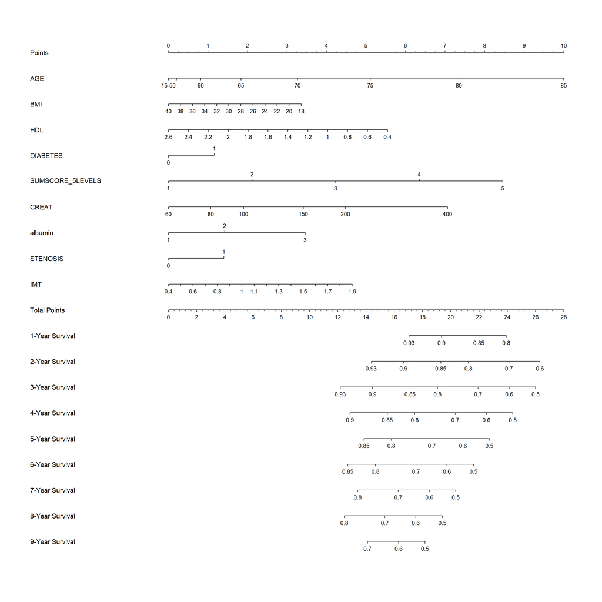

```r
COXPH.REDUCED.AREGIMPUTED_3 <-cph(Surv(TEVENT,EVENT) ~  ifelse(AGE>50, (AGE-50)^2,0) +
                                 BMI +
                                 HDL+
                                 DIABETES +
                                 SUMSCORE_5LEVELS +
                                 log(CREAT) +
                                 albumin +
                                 STENOSIS +
                                 IMT,
                               data = SMART.AREGIMPUTED_3,
                               surv=T)

dd <- datadist(SMART.AREGIMPUTED_3)
options(datadist="dd")

COXPH.REDUCED.AREGIMPUTED_3.PreNomogram <- Survival(COXPH.REDUCED.AREGIMPUTED_3)

COXPH.REDUCED.AREGIMPUTED_3.Nomogram <- nomogram(COXPH.REDUCED.AREGIMPUTED_3,
                                                 fun=list(function(x) COXPH.REDUCED.AREGIMPUTED_3.PreNomogram(365,x),
                                                          function(x) COXPH.REDUCED.AREGIMPUTED_3.PreNomogram(730,x),
                                                          function(x) COXPH.REDUCED.AREGIMPUTED_3.PreNomogram(1095,x),
                                                          function(x) COXPH.REDUCED.AREGIMPUTED_3.PreNomogram(1460,x),
                                                          function(x) COXPH.REDUCED.AREGIMPUTED_3.PreNomogram(1825,x),
                                                          function(x) COXPH.REDUCED.AREGIMPUTED_3.PreNomogram(2190,x),
                                                          function(x) COXPH.REDUCED.AREGIMPUTED_3.PreNomogram(2555,x),
                                                          function(x) COXPH.REDUCED.AREGIMPUTED_3.PreNomogram(2920,x),
                                                          function(x) COXPH.REDUCED.AREGIMPUTED_3.PreNomogram(3285,x)),
                                                 funlabel=c("1-Year Survival",
                                                            "2-Year Survival",
                                                            "3-Year Survival",
                                                            "4-Year Survival",
                                                            "5-Year Survival",
                                                            "6-Year Survival",
                                                            "7-Year Survival",
                                                            "8-Year Survival",
                                                            "9-Year Survival"),
                                                 AGE=c(15,seq(50,85,5)),
                                                 CREAT=c(60,80,100,150,200,400),
                                                 lp.at=c(0,1,2,2.4),
                                                 fun.at=c(0.93,0.90,0.85,0.80,0.70,0.60,0.50),
                                                 lp=FALSE,
                                                 maxscale=10)

plot(COXPH.REDUCED.AREGIMPUTED_3.Nomogram)
```

## 1.3 Model Validity Evaluation

### 1.3.1 Internal Overfitting

Internal overfitting was effectively managed by using a sufficiently large sample size in the study, considering literature and previous research results in the choice of candidate predictors and employing an objective selection of the final predictors.

### 1.3.2 External Generalizability

Although, external generalizability was not particularly assessed in the study, a large set of predictors representing important domains related to the subject matter was considered to ensure that the predictions made from the model are valid for plausibly related populations.

# **2. Summary**

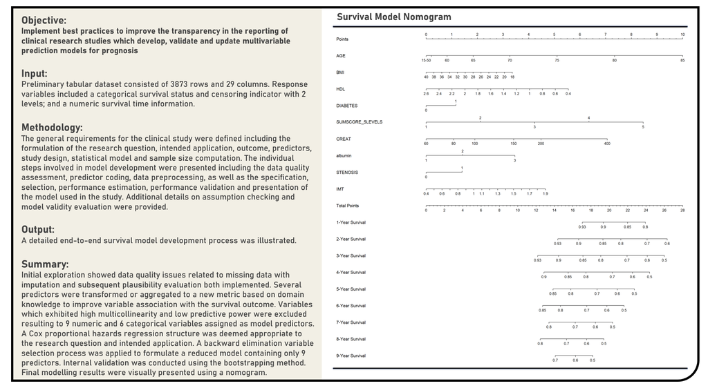

# **3. References**

**[Book]** [Clinical Prediction Models](http://clinicalpredictionmodels.org/) by Ewout Steyerberg  
**[Book]** [Survival Analysis: A Self-Learning Text](https://link.springer.com/book/10.1007/978-1-4419-6646-9/) by David Kleinbaum and Mitchel Klein  
**[Book]** [Applied Survival Analysis Using R](https://link.springer.com/book/10.1007/978-3-319-31245-3/) by Dirk Moore  
**[Book]** [Regression Modeling Strategies](https://link.springer.com/book/10.1007/978-3-319-19425-7/) by Frank Harrell  
**[Book]** [R for Health Data Science](https://argoshare.is.ed.ac.uk/healthyr_book/) by Ewen Harrison and Riinu Pius  
**[Book]** [Supervised Machine Learning](https://bookdown.org/mpfoley1973/supervised-ml/) by Michael Foley  
**[Book]** [Data Science for Biological, Medical and Health Research](https://thomaselove.github.io/432-notes/index.html) by Thomas Love  
**[R Package]** [survival](https://cran.microsoft.com/snapshot/2022-04-01/web/packages/survival/index.html/) by Terry Therneau  
**[R Package]** [survminer](https://cran.r-project.org/web/packages/survminer/index.html/) by Alboukadel Kassambara  
**[R Package]** [mice](https://www.gerkovink.com/miceVignettes/) by Gerko Vink and Stef van Buuren  
**[R Package]** [foreign](https://cran.r-project.org/web/packages/foreign/index.html/) by R Core Team  
**[R Package]** [rms](https://cran.r-project.org/web/packages/rms/index.html/) by Frank Harrell  
**[R Package]** [Hmisc](https://cran.r-project.org/web/packages/Hmisc//) by Frank Harrell and Charles Dupont  
**[R Package]** [VIM](https://cran.r-project.org/web/packages/VIM/index.html/) by Matthias Templ  
**[R Package]** [gridExtra](https://cran.microsoft.com/snapshot/2017-08-01/web/packages/gridExtra/index.html/) by Baptiste Auguie  
**[R Package]** [finalfit](https://cran.r-project.org/web/packages/finalfit/index.html/) by Ewen Harrison  
**[R Package]** [knitr](https://cran.r-project.org/web/packages/knitr/index.html/) by Yihui Xie  
**[R Package]** [dplyr](https://cran.r-project.org/web/packages/dplyr/index.html/) by Hadley Wickham  
**[R Package]** [gtsummary](https://cran.r-project.org/web/packages/gtsummary/index.html/) by Daniel Sjoberg  
**[R Package]** [tidyr](https://cran.r-project.org/web/packages/tidyr/index.html/) by Hadley Wickham  
**[R Package]** [purrr](https://cran.r-project.org/web/packages/purrr//) by Lionel Henry  
**[R Package]** [moments](https://cran.r-project.org/web/packages/moments/index.html) by Lukasz Komsta and Frederick Novomestky  
**[R Package]** [lattice](https://cran.r-project.org/web/packages/lattice/index.html) by Deepayan Sarkar  
**[Article]** [Survival Analysis](https://sphweb.bumc.bu.edu/otlt/MPH-Modules/BS/BS704_Survival/index.html) by Lisa Sullivan

**[Article]** [Survival Analysis in R](https://www.emilyzabor.com/tutorials/survival_analysis_in_r_tutorial.html) by Emily Zabor  
**[Article]** [Assessment of Discrimination in Survival Analysis](https://rstudio-pubs-static.s3.amazonaws.com/3506_36a9509e9d544386bd3e69de30bca608.html) by R-Studio Team  
**[Article]** [Cox Proportional-Hazards Regression](https://www.medcalc.org/manual/cox-regression.php) by MedCalc Team  
**[Article]** [Cox Proportional-Hazards Model](https://rstudio-pubs-static.s3.amazonaws.com/3506_36a9509e9d544386bd3e69de30bca608.html) by R Studio Team  
**[Article]** [Exploring Time To Event / Survival Data](https://thomaselove.github.io/432-notes/exploring-time-to-event-survival-data.html) by Thomas Love  
**[Article]** [Survival Analysis](http://www.sthda.com/english/wiki/survival-analysis) by Alboukadel Kassambara  
**[Article]** [Survival Analysis with R](https://rviews.rstudio.com/2017/09/25/survival-analysis-with-r/) by Joseph Rickert  
**[Article]** [Cox Model Assumptions](http://www.sthda.com/english/wiki/cox-model-assumptions#testing-non-linearity) by Alboukadel Kassambara  
**[Article]** [Understanding Predictions in Survival Analysis](https://scikit-survival.readthedocs.io/en/stable/user_guide/understanding_predictions.html) by Scikit Team  
**[Publication]** [Standards for Reporting Diagnostic Accuracy Studies (STARD): Explanation and Elaboration](https://www.equator-network.org/reporting-guidelines/stard/) by Patrick Bosuyt (British Medical Journal)  
**[Publication]** [Transparent Reporting of a Multivariable Prediction Model for Individual Prognosis Or Diagnosis (TRIPOD): Explanation and Elaboration](https://www.acpjournals.org/doi/10.7326/M14-0698) by Karel Moons (Annals of Internal Medicine)  
**[Publication]** [A Tool to Assess Risk of Bias and Applicability of Prediction Model Studies (PROBAST): Explanation and Elaboration](https://www.acpjournals.org/doi/10.7326/M18-1377) by Karel Moons (Annals of Internal Medicine)  
**[Publication]** [Guide to Presenting Clinical Prediction Models for Use in Clinical Settings](https://www.bmj.com/content/365/bmj.l737#:~:text=Clinical%20prediction%20models%20estimate%20the%20risk%20of%20existing,such%20as%20logistic%20and%20Cox%20regression%20%28box%201%29.) by Laura J Bonnett, Kym Snell, Gary Collins and Richard Riley (British Medical Journal)  
**[Publication]** [Survival Analysis Part I: Basic Concepts and First Analyses](https://www.ncbi.nlm.nih.gov/pmc/articles/PMC2394262/) by Taane Clark (British Journal of Cancer)  
**[Publication]** [Survival Analysis Part II: Multivariate Data Analysis – An Introduction to Concepts and Methods](https://www.ncbi.nlm.nih.gov/pmc/articles/PMC2394368/) by Mike Bradburn (British Journal of Cancer)  
**[Publication]** [Survival Analysis Part III: Multivariate Data Analysis – Choosing a Model and Assessing its Adequacy and Fit](https://www.ncbi.nlm.nih.gov/pmc/articles/PMC2376927/) by Mike Bradburn (British Journal of Cancer)  
**[Publication]** [Survival Analysis Part IV: Further Concepts and Methods in Survival Analysis](https://www.ncbi.nlm.nih.gov/pmc/articles/PMC2394469/) by Taane Clark (British Journal of Cancer)  
**[Tutorial]** [Survival Analysis / Time-To-Event Analysis in R](https://campus.datacamp.com/courses/survival-analysis-in-r/what-is-survival-analysis?ex=1) by Heidi Seibold (Datacamp)